# Regular Expressions Tutorial

Steve Dutky MC Data110 Fall 2019

12/5/2019

## - start

## First the dirty work you can ignore for now

### set the seed for generating repeatable random numbers

```r
set.seed(19181112)
```

### load the libraries

```r
library(tidyverse)
library(lubridate)
```

```r
library(ggplot2)
library(ggwordcloud)
```

### A useful function extract matching regular expressions from a character expression or vector

```r
getRegEx<-function(re, v) {
  # extract all strings matching regular expression re in
  # input text or vector v
  vectorResult<-c() # initialize vector container for matches
  v<-v[grep(re,v)] # line up the first candidates for macthing

  while (length(v) >0 ) { # any candidates left?
    matchStart<-regexpr(re,v)
    matchEnd<-matchStart+attr(matchStart,"match.length")-1
    endOfString<-nchar(v)

    # add matching strings to results
    vectorResult<-c( vectorResult,
                     substr(v,matchStart,matchEnd)
                  )

    # remove matching strings from candidates
    v<-paste(substr(v,1,matchStart-1),substr(v,matchEnd+1,endOfString),sep="")
    v<-v[grep(re,v)]  # line up remaining candidates
  }

  return(vectorResult)

}
```

### return ggwordcloud plot of words, frequency, optional params

```r
require(ggwordcloud)

myGgWordCloud<-function(wordSpec, max_size=24,title="",caption="") {
#  wordSpec is a tibble with required column names words and frquency
#    if not specified, columns angle and color will be generated as below
# max_size is in points, title and caption are usual ggplot args
if (!("angle" %in% names(wordSpec))) {
        wordSpec <- wordSpec %>%
                mutate(angle = 45 * sample(-2:2, n(), replace = TRUE, prob = c(1, 2, 4, 2, 1)))
}

if (!("color" %in% names(wordSpec))) {
        wordSpec <- wordSpec %>%
                mutate(color = factor(sample.int(10, nrow(wordSpec), replace = TRUE)))
}

plotReturn<-ggplot(
  wordSpec,
  aes(
    label = words, size = frequency,
    color = color,
    angle = angle
  )
) +
  geom_text_wordcloud_area(area_corr = TRUE) +
  scale_size_area(max_size = max_size) +
  labs(title=title, caption = caption) +
  theme_set(theme_minimal(base_size = 15))
  theme_minimal()

return(plotReturn)
}
```

### - next

’’

[figure not shown]

### - next

’’

[figure not shown]

### next

’’

[figure not shown]

### [apologies to Randall Munroe xkcd.com](https://xkcd.com/208/)

#### next

## DATA 110 background:

### As part of web scraping we were introduced to the R function **gsub(“this”, “for that”, v)** which replaces all occurences of “this” with “for that” in variable v:

#### next

```r
richardII<-c(
    "THIS EXAMPLE from Shakespeare's Richard II:",
    "",
    "1050. Gaunt: This royal throne of kings, this sceptred isle,",
    "This earth of majesty, this seat of Mars,",
    "This other Eden, demi-paradise,",
    "This fortress built by Nature for herself",
    "Against infection and the hand of war,",
    "1055. This happy breed of men, this little world,",
    "This precious stone set in the silver sea,",
    "Which serves it in the office of a wall",
    "Or as a moat defensive to a house,",
    "Against the envy of less happier lands,--",
    "1060. This blessed plot, this earth, this realm, this England.",
    "<snip>",
    "Yorke: The King is come, deale mildly with his youth,"
)
```

#### next

```r
print(gsub("this", "for that", richardII))
```

```
##  [1] "THIS EXAMPLE from Shakespeare's Richard II:"
##  [2] ""
##  [3] "1050. Gaunt: This royal throne of kings, for that sceptred isle,"
##  [4] "This earth of majesty, for that seat of Mars,"
##  [5] "This other Eden, demi-paradise,"
##  [6] "This fortress built by Nature for herself"
##  [7] "Against infection and the hand of war,"
##  [8] "1055. This happy breed of men, for that little world,"
##  [9] "This precious stone set in the silver sea,"
## [10] "Which serves it in the office of a wall"
## [11] "Or as a moat defensive to a house,"
## [12] "Against the envy of less happier lands,--"
## [13] "1060. This blessed plot, for that earth, for that realm, for that England."
## [14] "<snip>"
## [15] "Yorke: The King is come, deale mildly with his youth,"
```

#### next

### The first argument “this” is in this case a literal string, but is actually a pattern of literal characters and codes that form **regular expressions** These form a versatile way of matching, manipulating, and cleaning text. In the next four minutes we’re going to cover some of their basic features and the functions that use them.

#### next

## And what are regular expressions good for?

#### next

### fixing up phone numbers

```
## # A tibble: 10 x 2
##    original               formatted
##    <chr>                  <chr>
##  1 136-540-1970           (136) 540-1970
##  2 967-469-4943           (967) 469-4943
##  3 515-071-8078           (515) 071-8078
##  4 163.070.3292 1234      (163) 070-3292 ext. 1234
##  5 (621) 902-2951 ext 220 (621) 902-2951 ext. 220
##  6 985-954-1652           (985) 954-1652
##  7 668.771.5174           (668) 771-5174
##  8 (418) 915-8969         (418) 915-8969
##  9 3233449931             (323) 344-9931
## 10 835-255-3199           (835) 255-3199
```

#### next

### fixing up names

```
## # A tibble: 10 x 4
##    fullName                             lastName    firstName   middleName
##    <chr>                                <chr>       <chr>       <chr>
##  1 "  David       R      Al-Hashimi"    Al-Hashimi  David       R
##  2 "Christopher L      Brown     "      Brown       Christopher L
##  3 "Davis-Mbali,    Jane              " Davis-Mbali Jane        <NA>
##  4 "Garcia,   Daniel      S      "      Garcia      Daniel      S
##  5 "Jones,    James       D      "      Jones       James       D
##  6 "O'Brien,  Roberta     June      "   O'Brien     Roberta     June
##  7 "Rodriguez,Brian       C      "      Rodriguez   Brian       C
##  8 "Smith,    John        M      "      Smith       John        M
##  9 Thomas,   Joseph      Anthony        Thomas      Joseph      Anthony
## 10 "Williams, Michael     A      "      Williams    Michael     A
```

#### next

### text mining

#### next

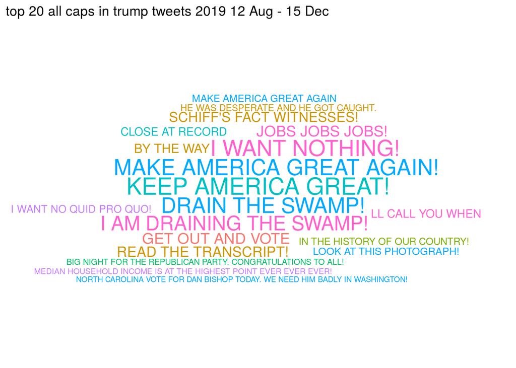

### -

#### next

### -

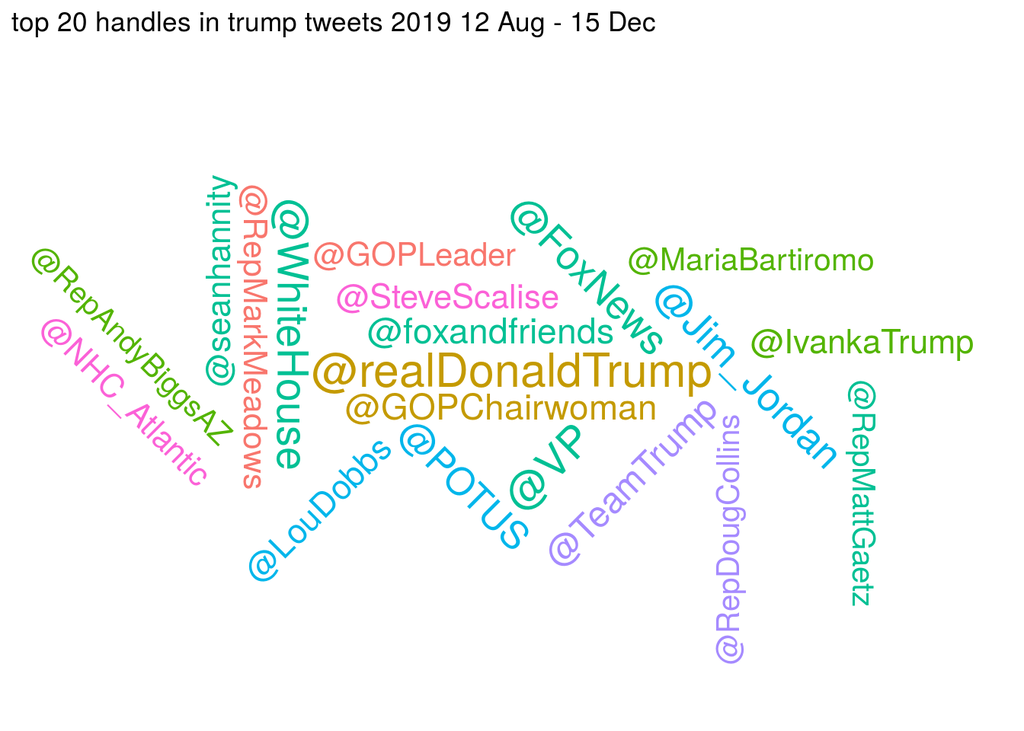

### -

#### next

### -

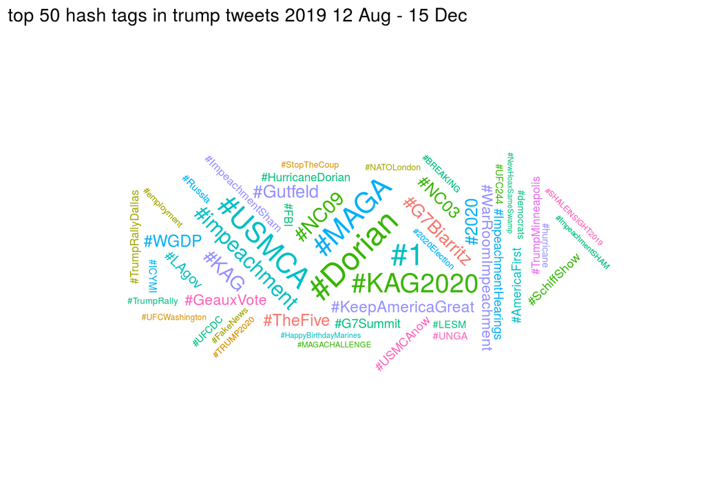

### -

#### next

### -

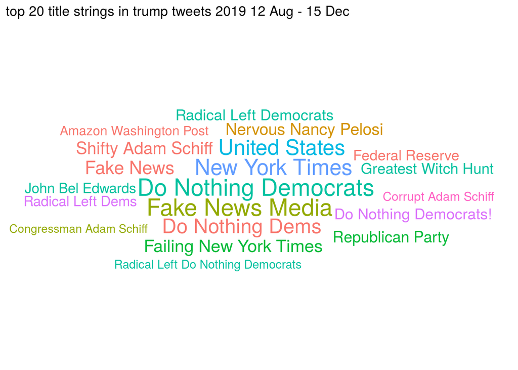

#### next

## Who uses and Where can you use **regular expressions**?

### The short answer is coders of many apps and languages:

### [R](https://stat.ethz.ch/R-manual/R-devel/library/base/html/regex.html)

### [python](https://docs.python.org/3/library/re.html)

### [java](https://www.vogella.com/tutorials/JavaRegularExpressions/article.html)

### [javascript](https://developer.mozilla.org/en-US/docs/Web/JavaScript/Guide/Regular_Expressions)

### shell scripts, perl, PowerShell

### [Tableau](https://www.tableau.com/about/blog/2015/6/become-regular-regular-expressions-39802)

### even [Excel](https://medium.com/@jrcharney/excel-vba-regular-expression-functions-800147f64c95) after the usual bending over [backwards](https://stackoverflow.com/questions/22542834/how-to-use-regular-expressions-regex-in-microsoft-excel-both-in-cell-and-loops)

### [Google Search](https://webapps.stackexchange.com/questions/19673/is-there-a-way-to-search-in-google-using-regular-expressions-regex) supports some regular expressions: try (gray|red) (fox|wolf)

#### next

## Regular Expressions: the essentials:

- **Anchors:** ^ matches the start of text, $ matches the end,
- **Character Classes:**
  - [string] matches one of characters in string
  - [a-z] matches one lowercase letter
  - [A-Z] matches one uppercase letter
  - [0-9] matches one digit
  - [^A-Z] matches one character that is not an uppercase letter
  - [^A-Za-z0-9] matches one character that is not any of these, ie. one punctuation mark.
  - . matches any single character
- **Character Codes: prefixed in R by doubble escapes \\**
  - \\w \\W word/non word characters [A-Z0-9a-z_] / [^A-Z0-9a-z_]
  - \\s \\S whitespace/non whitespace characters [ \\r\\t\\n] / [^ \\r\\t\\n]
  - \\d \\D digit/non digit [0-9] / [^0-9]
  - \\b \\B word boundary / non word boundary
  - \\n \\r \\f \\t newline, return, formfeed, tab
- **Quantifiers:**
  - *regex** matches regular expression *regex* 0 or more times
  - *regex*? matches regular expression *regex* 1 or 0 times
  - *regex*+ matches *regex* 1 or more times
  - *regex*{count} matches regex exactly *count* times
  - *regex*{min,} matches regex at least min times
  - *regex*{min,max} matches regex at least min times but no more than max
  - *regex*{,max} matches regex no more than max times

#### next

- **Combining & capturing:**
  - (*regex1*|*regex2*) matches one instance of regex1 or regex2
  - (*regex*) “captures” *regex*
  - (?:*regex*) non capturing grouping
  - *\\1* to *\\9* backreferences used to refer to captured *regex* in replacement
- **Named Character Classes: operate only within brackets**
  - [:alnum:] Alphanumeric characters [a-zA-Z0-9]
  - [:alpha:] Alphabetic characters [a-zA-Z]
  - [:ascii:] ASCII characters [\\x00-\\x7F]
  - [:blank:] Space and tab [ \\t]
  - [:cntrl:] Control characters [\\x00-\\x1F\\x7F]
  - [:digit:] Digits [0-9]
  - [:graph:] Visible characters [\\x21-\\x7E]
  - [:lower:] Lowercase letters [a-z]
  - [:print:] Visible characters and spaces [\\x20-\\x7E]
  - [:punct:] Punctuation (and symbols) [^A-Za-z0-9 ]
  - [:space:] All whitespace characters, including line breaks
  - [:upper:] Uppercase letters [A-Z]
  - [:word:] Word characters [A-Za-z0-9_]
  - [:xdigit:] Hexadecimal Digits [0-9A-Fa-f]

#### next

## What can you do with **regular expressions**?

> **in the simple cases:**

### **grep(** **regex**,**string**,value=FALSE,invert=FALSE) example

#### grep is an acronym for “get regular expression”

#### with the default arguments, it returns the indices of string that match regex

#### with invert=TRUE, it returns the indices of string that don’t match regex

#### with value=TRUE, it returns the values of string

### **grepl(** **regex**,**string**) example

#### grep logical, returns a logical vector TRUE wherever string matches regex

#### !grepl returns a logical vector TRUE wherever string does not match regex

#### grepl is particularly useful in filtering a dplyr pipeline

### **sub(** **regex**,**replacement**,**string**) example

#### returns a string where the first match of regex is changed to replacement

### **gsub(** **regex**,**replacement**,**string**) example

#### returns a string where all matches of regex are changed to replacement

### **strsplit(** **string**,**regex**) example

#### returns a list the length of string.

#### each element of the list contains a vector,

#### whose elements are formed by dividing string at the matches of regex

### **matchStart**<-**regexpr(** **regex**,**strings**) example

#### **matchStart** is a vector the length of strings

#### whose each element is the index of the first match in the corresponding element of strings,

#### **attr(matchStart,“match.length”)** contains the length of the first match in the corresponding element of strings,

#### wherever there is no match, **matchStart** and **attr(matchStart,“match.length”)** contain -1.

#### next

## Example: Formatting Phone Numbers back

> Everybody has a favorite way of formatting phone numbers.  
> Let’s make these as ( <area code> ) <exchange> <line> ext. <extension>

```r
originalPhones<-c("136-540-1970", "967-469-4943", "515-071-8078", "163.070.3292 1234", "(621) 902-2951 ext 220", "985-954-1652", "668.771.5174", "(418) 915-8969", "3233449931", "835-255-3199")

print(c("original phone numbers",originalPhones))
```

```
##  [1] "original phone numbers" "136-540-1970"
##  [3] "967-469-4943"           "515-071-8078"
##  [5] "163.070.3292 1234"      "(621) 902-2951 ext 220"
##  [7] "985-954-1652"           "668.771.5174"
##  [9] "(418) 915-8969"         "3233449931"
## [11] "835-255-3199"
```

```r
# we do this in two passes. First, let's extract all numbers:

formattedPhones<-sub(
        "^\\D*(\\d{3})\\D*(\\d{3})\\D*(\\d{4})\\D*(\\d*)$",
# From the beginning, ignore any non-digits, capture 3 digits then
#                     ignore any non-digits, capture 3 digits then
#                     ignore any non-digits, capture 4 digits then
#                     ignore any non-digits, capture any digits to the end
        "(\\1) \\2-\\3 ext. \\4",
        originalPhones
        )
# Second remove the trailing space for all the numbers that have no extension:
formattedPhones<-sub(" ext\\. $","",formattedPhones)
# note "\\." to specify period

cat("\n")
```

```r
print(c("formatted phone numbers",formattedPhones))
```

```
##  [1] "formatted phone numbers"  "(136) 540-1970"
##  [3] "(967) 469-4943"           "(515) 071-8078"
##  [5] "(163) 070-3292 ext. 1234" "(621) 902-2951 ext. 220"
##  [7] "(985) 954-1652"           "(668) 771-5174"
##  [9] "(418) 915-8969"           "(323) 344-9931"
## [11] "(835) 255-3199"
```

#### next

## Let’s clean up a bunch of messy full names and split them into last, first, middle:

```r
# a function to do that
nameConvert<-function(fullName) {
  # function to return tibble with full, first, middle, and last names

  # initialize tibble for return to function caller
  xfr<-tibble(fullName="",lastName="",firstName="",middleName="")
  xfr<-xfr[-1,]  # leaves only the tibble header w/o rows
  # code continues after internal function definition:

  getNames<-function(fullName) {
    # internal function to extract name chunks from fullName
    if (grepl(",",fullName)) {
      # name in format last, first middle name/initial
      # use capture group in parentheses to extract each name
      # in form  <any white space><name><any white>
      # swallow the entire fullName from beginning to end.

      regex="^\\s*([A-Za-z'\\-]+)\\s*,.*$"
      lastName<-sub(regex,"\\1",fullName)
      regex="^\\s*[A-Za-z'\\-]+\\s*,\\s*([A-Za-z'\\-]+).*$"
      firstName<-sub(regex,"\\1",fullName)
      regex="^\\s*[A-Za-z'\\-]+\\s*,\\s*[A-Za-z'\\-]+\\s*([A-Za-z'\\-]*).*$"
      middleName<-sub(regex,"\\1",fullName)

    } else {
      # name in format , first { optional middle name/initial } last
      # use capture group in parentheses to extract each name
      # in form  <any white space><name><any white>
      # swallow the entire fullName from beginning to end.

      regex="^\\s*([A-Za-z'\\-]+)\\s*.*$"
      firstName<-sub(regex,"\\1",fullName)
      regex="^\\s*[A-Za-z'\\-]+\\s*([A-Za-z'\\-]+).*$"
      middleName<-sub(regex,"\\1",fullName)
      regex="^\\s*[A-Za-z'\\-]+\\s*[A-Za-z'\\-]+\\s*([A-Za-z'\\-]*).*$"
      lastName<-sub(regex,"\\1",fullName)

      # handle case where no middle name/initial: last misinterpretted as middle
      if (lastName=="") { lastName<-middleName; middleName<-NA}
    }

    if (middleName=="") middleName<-NA

    return (tibble(  # new row for adding
      fullName=fullName,
      lastName=lastName,
      firstName=firstName,
      middleName=middleName)
    )
  }
  # use internal function to extract names, then add row to xfr
  #      there's probably a better way to do this with dplyr and an apply function
  for ( fullN in fullName ) xfr<-rbind(xfr,getNames(fullN))
  return(xfr)
}
```

#### next

```r
library(stringr)

myData<-tibble(
  fullName=c(
    "Williams, Michael     A      ",
    "Christopher L      Brown     ",
    "$Smith,    John        M$      ",
    "O'Brien,  Roberta     June      ",
    "Jones,    James       D      ",
    "Rodriguez,Brian       C.      ",
    "Davis-Mbali,    JANE              ",
    "  David       R      Al-Hashimi",
    "Thomas,   Joseph      Anthony",
    "Garcia,   Daniel      S      "
  )#, lastName=NA,firstName=NA,middleName=NA
)

print("here are the original names:")
```

```
## [1] "here are the original names:"
```

```r
(myData)
```

```
## # A tibble: 10 x 1
##    fullName
##    <chr>
##  1 "Williams, Michael     A      "
##  2 "Christopher L      Brown     "
##  3 "$Smith,    John        M$      "
##  4 "O'Brien,  Roberta     June      "
##  5 "Jones,    James       D      "
##  6 "Rodriguez,Brian       C.      "
##  7 "Davis-Mbali,    JANE              "
##  8 "  David       R      Al-Hashimi"
##  9 Thomas,   Joseph      Anthony
## 10 "Garcia,   Daniel      S      "
```

```r
myCleanerData<- myData %>%
  # toss anything that's not a letter or acceptable punctuation
  # note double escape for whitespace, \\s, and hyphen, \\-
  # also note that \\s requires optional argument perl=TRUE
  mutate(fullName=gsub("[^\\sA-Za-z,'\\-]","",fullName,perl = TRUE)) %>%

  # capitalize first letter of every name using stringr function
  # note: fix up hack #1 to make O'brien => O'B... and Al-hashimi => Al-H...
  mutate(fullName=gsub("(['\\-])([A-Za-z])","\\1 \\2",fullName))  %>%
  mutate(fullName=str_to_title(fullName)) %>%
  mutate(fullName=gsub("(['\\-])[A-Za-z]","\\1 ",fullName))  %>%
  # undo fix up: remove space after "'" or "-"
  mutate(fullName=gsub("(['\\-]) ","\\1",fullName))

# There's probably a better way to do this with dplyr and an apply function:
#     I wimped out

myCleanData<-nameConvert(myCleanerData$fullName) #extract seperate names

# Let's sort them in alphabetic order by last, first, middle
myCleanData<- myCleanData %>%
  arrange( lastName, firstName, middleName )

# and out it goes:
(myCleanData)
```

```
## # A tibble: 10 x 4
##    fullName                             lastName    firstName   middleName
##    <chr>                                <chr>       <chr>       <chr>
##  1 "  David       R      Al-Hashimi"    Al-Hashimi  David       R
##  2 "Christopher L      Brown     "      Brown       Christopher L
##  3 "Davis-Mbali,    Jane              " Davis-Mbali Jane        <NA>
##  4 "Garcia,   Daniel      S      "      Garcia      Daniel      S
##  5 "Jones,    James       D      "      Jones       James       D
##  6 "O'Brien,  Roberta     June      "   O'Brien     Roberta     June
##  7 "Rodriguez,Brian       C      "      Rodriguez   Brian       C
##  8 "Smith,    John        M      "      Smith       John        M
##  9 Thomas,   Joseph      Anthony        Thomas      Joseph      Anthony
## 10 "Williams, Michael     A      "      Williams    Michael     A
```

#### next

## Trump’s tweets from whistleblower complaint until now..

### [Get Trump’s tweets](http://www.trumptwitterarchive.com/archive) as text:

```r
trumpsTweets.txt<-read_lines(url("https://raw.githubusercontent.com/sdutky/mcData110/master/regexTutorial/trumpTweets12Aug15Dec.txt"))

head(trumpsTweets.txt)
```

```
## [1] "08-12-2019 04:01:28"
## [2] "Thank you NEGOP! https://t.co/S5A24nleW8 [Twitter for iPhone]"
## [3] "08-12-2019 04:02:50"
## [4] "RT @TrumpWarRoom: Joe Biden: “Poor kids are just as bright and just as talented as white kids.” https://t.co/YhDSMnoRce [Twitter for iPhone]"
## [5] "08-12-2019 04:03:51"
## [6] "RT @marc_lotter: STRONG! The American economy is doing very well [under @realDonaldTrump] &amp; wages are up but we cannot rely on the media… [Twitter for iPhone]"
```

#### next

## We can see this follows the form:

```
> **<date>**
> **<text> [<source>]**
```

## Let’s extract the dates and times:

```r
dateTimeIndex<-grep("..-..-2019 ..:..:[0-9]{2}$",trumpsTweets.txt)
```

## Let’s break down the regular expression "..-..-2019 ..:..:[0-9]{2}$"

> **$** => look for lines ending with  
> **..-..** => two groups of two characters seperated by a hyphen  
> **2019** => literal **2019** followed by a space that is followed by  
> **..:** => any two characters followed by a colon followed by  
> **..:** => another any two characters followed by a colon and  
> **[0-9]{2}$** => exactly two digits followed by an end of line

## If we look at dateTimeIndex we can see it’s all odd numbers, and we can see that dateTimeIndex+1 is all even numbers:

```r
cat("\nhead(dateTimeIndex):\n")
```

```
##
## head(dateTimeIndex):
```

```r
head(dateTimeIndex)
```

```
## [1]  1  3  5  7  9 11
```

```r
cat("\nhead(dateTimeIndex+1):\n")
```

```
##
## head(dateTimeIndex+1):
```

```r
head(dateTimeIndex+1)
```

```
## [1]  2  4  6  8 10 12
```

```r
# and the dates and text

cat("\nhead(trumpsTweets.txt[dateTimeIndex]):\n")
```

```
##
## head(trumpsTweets.txt[dateTimeIndex]):
```

```r
head(trumpsTweets.txt[dateTimeIndex])
```

```
## [1] "08-12-2019 04:01:28" "08-12-2019 04:02:50" "08-12-2019 04:03:51"
## [4] "08-12-2019 19:31:56" "08-12-2019 19:32:03" "08-12-2019 19:33:09"
```

```r
cat("\nhead(trumpsTweets.txt[dateTimeIndex+1]):\n")
```

```
##
## head(trumpsTweets.txt[dateTimeIndex+1]):
```

```r
head(trumpsTweets.txt[dateTimeIndex+1])
```

```
## [1] "Thank you NEGOP! https://t.co/S5A24nleW8 [Twitter for iPhone]"
## [2] "RT @TrumpWarRoom: Joe Biden: “Poor kids are just as bright and just as talented as white kids.” https://t.co/YhDSMnoRce [Twitter for iPhone]"
## [3] "RT @marc_lotter: STRONG! The American economy is doing very well [under @realDonaldTrump] &amp; wages are up but we cannot rely on the media… [Twitter for iPhone]"
## [4] "Scaramucci who like so many others had nothing to do with my Election victory is only upset that I didn’t want him back in the Administration (where he desperately wanted to be). Also I seldom had time to return his many calls to me. He just wanted to be on TV! [Twitter for iPhone]"
## [5] "RT @WhiteHouse: JUST ANNOUNCED: President @realDonaldTrump will enforce a Clinton-era law to ensure that non-citizens do not abuse our publ… [Twitter for iPhone]"
## [6] "RT @RandPaul: Why is the United States always stuck paying for everyone when prosperous nations don’t pay their fair share? @RichardGrenell… [Twitter for iPhone]"
```

## So let’s make a tibble. We’re also going make a place holder for retweets

```r
trumpsTweets.tib<-tibble(
  date=trumpsTweets.txt[dateTimeIndex],
  tweet=trumpsTweets.txt[dateTimeIndex+1],
  retweetFrom=NA
)

str(trumpsTweets.tib)
```

```
## Classes 'tbl_df', 'tbl' and 'data.frame':    3810 obs. of  3 variables:
##  $ date       : chr  "08-12-2019 04:01:28" "08-12-2019 04:02:50" "08-12-2019 04:03:51" "08-12-2019 19:31:56" ...
##  $ tweet      : chr  "Thank you NEGOP! https://t.co/S5A24nleW8 [Twitter for iPhone]" "RT @TrumpWarRoom: Joe Biden: “Poor kids are just as bright and just as talented as white kids.” https://t.co/Yh"| __truncated__ "RT @marc_lotter: STRONG! The American economy is doing very well [under @realDonal…
##  $ retweetFrom: logi  NA NA NA NA NA NA ...
```

#### next

## Now we can start using dplyr to do more:

> We’re going to convert the dates to R’s favorite format Note the use of capturing parenthese and back references

```r
trumpsTweets.tib<- trumpsTweets.tib %>%
  mutate(
    date=parse_date_time(date,"%m-%d-%YHMS",tz="EST"),

    source=sub("^.*[[]([^]]*)[]] *$","\\1",tweet),
    tweet=sub("[[][^]]*[]] *$","",tweet),
    #  We're looking to get <source> from [<source>], so:
    #    find an open bracket then capture as many characters as possible
    #    that are not a close bracket, followed by a close bracket and
    #    any number of spaces at the end of the tweet.
    #    and put it into \\1 for a back reference replacement

    # isolate retweets, but keep the tweeter's handle
    retweetFrom=sub("^(?:RT (@[^:]+))*.*$","\\1",tweet),
    tweet=sub("^(?:RT @[^:]+: )","",tweet),

    #get rid of urls: either http or https followed by
    # :// followed by anything up to a space or end of tweet:
    tweet=gsub("http[s]*://.*( |$)","",tweet)

  )
```

#### next

- Twitter handles of others including retweets,
- Inclusion of hash tags,
- phrase where the first letter of each word is capitalized,
- And phrases in all caps optionally followed by !

#### next

## Now we can start dissecting trumps tweets

### First get the hashtags: #alphanumeric and/or underscores

```r
hashTags<-getRegEx("#[A-Za-z0-9_]+",trumpsTweets.tib$tweet)

# get the frequency of occurence in descending order
htTable<-sort( table(hashTags), decreasing = TRUE)
hashTags.tib<-tibble(
                words=names(htTable),
                frequency=htTable
                )
hashTags.tib
```

```
## # A tibble: 210 x 2
##    words               frequency
##    <chr>               <table>
##  1 #Dorian             32
##  2 #USMCA              25
##  3 #KAG2020            21
##  4 #MAGA               21
##  5 #impeachment        11
##  6 #1                   8
##  7 #G7Biarritz          6
##  8 #KeepAmericaGreat    6
##  9 #NC09                6
## 10 #WarRoomImpeachment  6
## # … with 200 more rows
```

### Now plot the word cloud of hash tags:

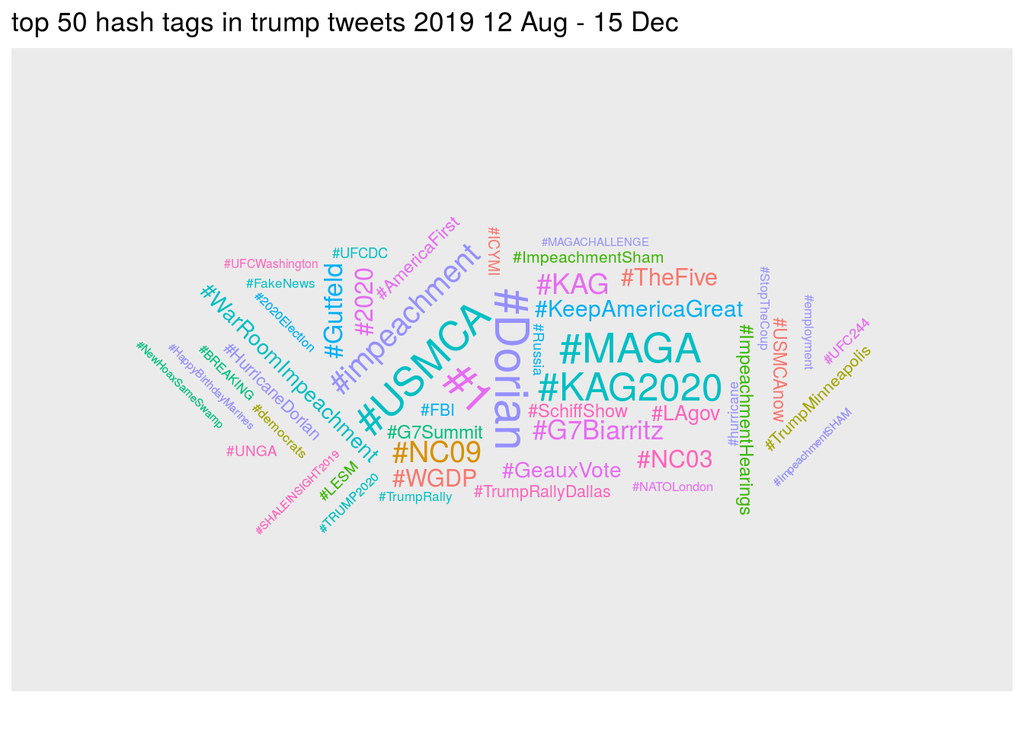

```r
a<-hashTags.tib[1:50,]
a$frequency<-log(a$frequency)

wcHashTags<-myGgWordCloud(a,title="top 50 hash tags in trump tweets 2019 12 Aug - 15 Dec",max_size = 8)
wcHashTags
```

#### next

### Now get the twitter handles: @alphanumeric and/or underscores; add in the retweeters, sort and tibblelize them:

```r
handles<-getRegEx("@[A-Za-z0-9_]+",trumpsTweets.tib$tweet)

handles<-c( handles, trumpsTweets.tib$retweetFrom[trumpsTweets.tib$retweetFrom!=""])

hanTable<-sort(table(handles),decreasing  =TRUE)

handles.tib<-tibble(
                words=names(hanTable),
                frequency=hanTable
                )
handles.tib
```

```
## # A tibble: 720 x 2
##    words            frequency
##    <chr>            <table>
##  1 @realDonaldTrump 453
##  2 @WhiteHouse      140
##  3 @Jim_Jordan       73
##  4 @FoxNews          69
##  5 @GOPChairwoman    64
##  6 @RepMarkMeadows   53
##  7 @foxandfriends    50
##  8 @TeamTrump        44
##  9 @POTUS            40
## 10 @SteveScalise     37
## # … with 710 more rows
```

### Plot the top 20 twitter handles in Trump’s tweets

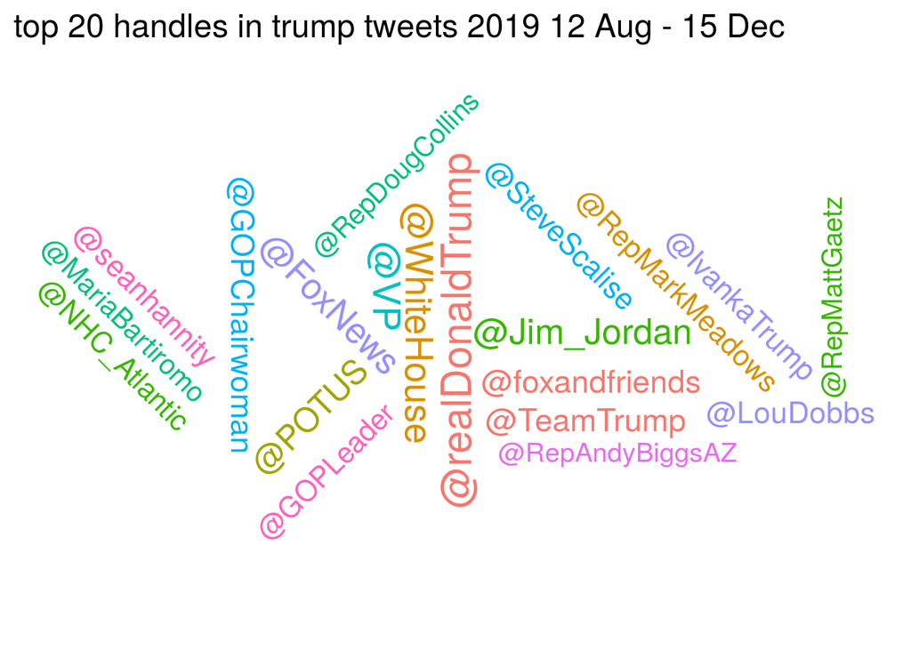

```r
# since Trump includes @realDonaldTrump more than anybody else,
# we will convert frequency to log(frequency)
a<-handles.tib[1:20,]
a$frequency<-log(a$frequency)

wcHandles<-myGgWordCloud(a,title="top 20 handles in trump tweets 2019 12 Aug - 15 Dec",max_size = 8)
wcHandles
```

#### next

### And the all-in-caps phrases:

- “[A-Z’]+” => first word followed by a space
- "(?:[A-Z.’]+( |!|$)){2,} => at least two more words followed by either a space, exclamation point or end of line.

```r
allCaps<-getRegEx("[A-Z']+ (?:[A-Z.']+( |!|$)){2,}",trumpsTweets.tib$tweet)

allCapsTable<-sort(table(allCaps), decreasing = TRUE)

allCaps.tib<-tibble(
                words=names(allCapsTable),
                frequency=allCapsTable
                )
allCaps.tib
```

```
## # A tibble: 156 x 2
##    words                                                       frequency
##    <chr>                                                       <table>
##  1 KEEP AMERICA GREAT!                                         6
##  2 MAKE AMERICA GREAT AGAIN!                                   6
##  3 DRAIN THE SWAMP!                                            5
##  4 I AM DRAINING THE SWAMP!                                    5
##  5 I WANT NOTHING!                                             5
##  6 "GET OUT AND VOTE "                                         3
##  7 JOBS JOBS JOBS!                                             3
##  8 READ THE TRANSCRIPT!                                        3
##  9 SCHIFF'S FACT WITNESSES!                                    3
## 10 BIG NIGHT FOR THE REPUBLICAN PARTY. CONGRATULATIONS TO ALL! 2
## # … with 146 more rows
```

### Plot Trumps All Caps Phrases

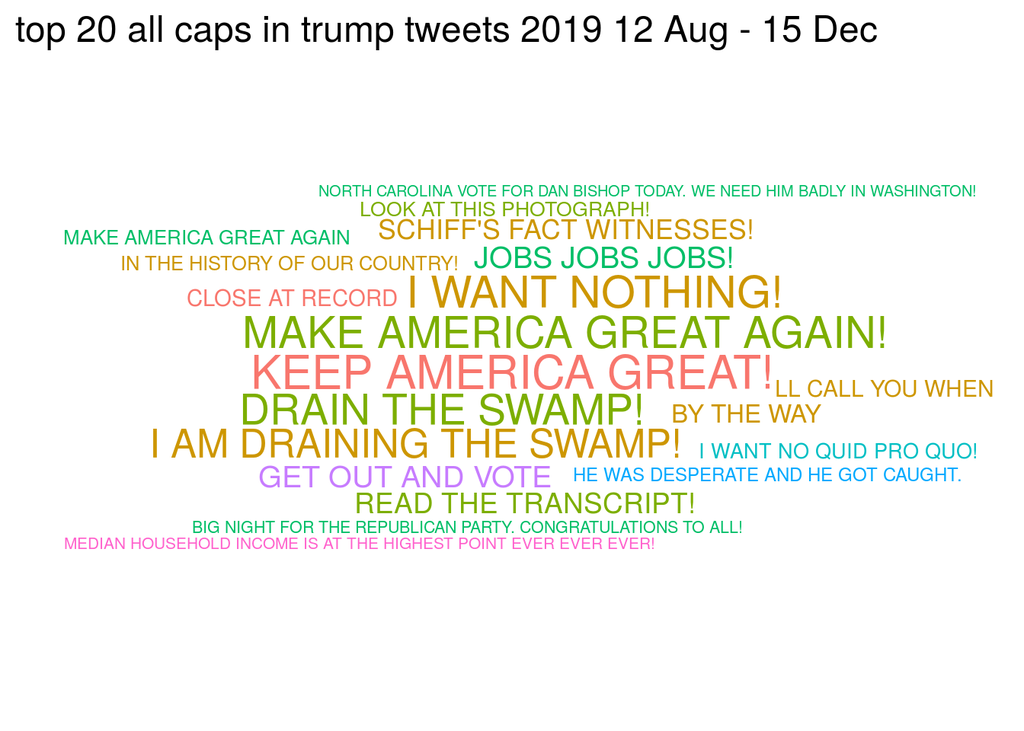

```r
a<-allCaps.tib[1:20,]
a$angle<-0  # display all phrases horizontally

wcAllCaps<-myGgWordCloud(a,title="top 20 all caps in trump tweets 2019 12 Aug - 15 Dec",max_size = 8)
wcAllCaps
```

#### top

### Title Strings: first letter of each word capitalized

```r
titleStrings<-getRegEx("[A-Z][a-z]+ (?:[A-Z][a-z]+( |!|$)){2,}",trumpsTweets.tib$tweet)

# remove beginning The's
titleStrings<-gsub("^The ","",titleStrings)

titleTable<-sort(table(titleStrings),decreasing = TRUE)

titleStrings.tib<-tibble(
                    words=names(titleTable),
                    frequency=titleTable
                  )
titleStrings.tib
```

```
## # A tibble: 698 x 2
##    words                     frequency
##    <chr>                     <table>
##  1 "Do Nothing Democrats "   34
##  2 "Fake News Media "        27
##  3 "New York Times "         16
##  4 "Do Nothing Dems "        14
##  5 "United States "          14
##  6 "Failing New York Times " 10
##  7 "Nervous Nancy Pelosi "    8
##  8 "Shifty Adam Schiff "      8
##  9 Do Nothing Democrats!      7
## 10 "Fake News "               7
## # … with 688 more rows
```

### Plot the top 20 title strings:

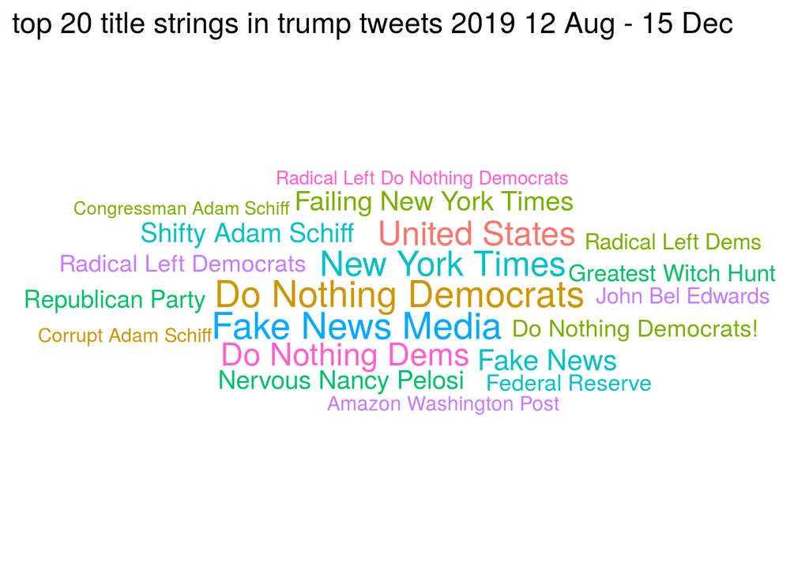

```r
a<-titleStrings.tib[1:20,]
a$frequency<-log(a$frequency)
a$angle<-0  # display all phrase horizontally

wcTitleStrings<-myGgWordCloud(a,title="top 20 title strings in trump tweets 2019 12 Aug - 15 Dec",max_size = 8)
wcTitleStrings
```

### **grep(** **regex**,**string**,value=FALSE,invert=FALSE) back

#### grep is an acronym for “get regular expression”

#### with the default arguments, it returns the indices of string that match regex

#### with invert=TRUE, it returns the indices of string that don’t match regex

#### with value=TRUE, it returns the values of string

```r
richardII
```

```
##  [1] "THIS EXAMPLE from Shakespeare's Richard II:"
##  [2] ""
##  [3] "1050. Gaunt: This royal throne of kings, this sceptred isle,"
##  [4] "This earth of majesty, this seat of Mars,"
##  [5] "This other Eden, demi-paradise,"
##  [6] "This fortress built by Nature for herself"
##  [7] "Against infection and the hand of war,"
##  [8] "1055. This happy breed of men, this little world,"
##  [9] "This precious stone set in the silver sea,"
## [10] "Which serves it in the office of a wall"
## [11] "Or as a moat defensive to a house,"
## [12] "Against the envy of less happier lands,--"
## [13] "1060. This blessed plot, this earth, this realm, this England."
## [14] "<snip>"
## [15] "Yorke: The King is come, deale mildly with his youth,"
```

```r
# look for literal string "ess"
grep("ess",richardII)
```

```
## [1]  6 12 13
```

```r
richardII[grep("ess",richardII)]
```

```
## [1] "This fortress built by Nature for herself"
## [2] "Against the envy of less happier lands,--"
## [3] "1060. This blessed plot, this earth, this realm, this England."
```

```r
# look for commas in the middle
grep("[a-z], [a-z]",richardII)
```

```
## [1]  3  4  5  8 13 15
```

```r
richardII[grep("[a-z], [a-z]",richardII)]
```

```
## [1] "1050. Gaunt: This royal throne of kings, this sceptred isle,"
## [2] "This earth of majesty, this seat of Mars,"
## [3] "This other Eden, demi-paradise,"
## [4] "1055. This happy breed of men, this little world,"
## [5] "1060. This blessed plot, this earth, this realm, this England."
## [6] "Yorke: The King is come, deale mildly with his youth,"
```

```r
# look for capital letters not at the beginning
grep(".[A-Z]",richardII)
```

```
## [1]  1  3  4  5  6  8 13 15
```

```r
richardII[grep(".[A-Z]",richardII)]
```

```
## [1] "THIS EXAMPLE from Shakespeare's Richard II:"
## [2] "1050. Gaunt: This royal throne of kings, this sceptred isle,"
## [3] "This earth of majesty, this seat of Mars,"
## [4] "This other Eden, demi-paradise,"
## [5] "This fortress built by Nature for herself"
## [6] "1055. This happy breed of men, this little world,"
## [7] "1060. This blessed plot, this earth, this realm, this England."
## [8] "Yorke: The King is come, deale mildly with his youth,"
```

### Look for lines that begin with one or more digits and return their values

```r
grep("^\\d+",richardII,value = TRUE)
```

```
## [1] "1050. Gaunt: This royal throne of kings, this sceptred isle,"
## [2] "1055. This happy breed of men, this little world,"
## [3] "1060. This blessed plot, this earth, this realm, this England."
```

### **grepl(** **regex**,**string**) back

#### grep logical, returns a logical vector TRUE wherever string matches regex

#### !grepl returns a logical vector TRUE wherever string does not match regex

#### grepl is particularly useful in filtering a dplyr pipeline

```r
# make richardII a tibble and pipe it to a filter:
tibble(text=richardII) %>%
  filter(grepl(".[A-Z]",text)) # still looking for uppercase in the middle
```

```
## # A tibble: 8 x 1
##   text
##   <chr>
## 1 THIS EXAMPLE from Shakespeare's Richard II:
## 2 1050. Gaunt: This royal throne of kings, this sceptred isle,
## 3 This earth of majesty, this seat of Mars,
## 4 This other Eden, demi-paradise,
## 5 This fortress built by Nature for herself
## 6 1055. This happy breed of men, this little world,
## 7 1060. This blessed plot, this earth, this realm, this England.
## 8 Yorke: The King is come, deale mildly with his youth,
```

### **sub(** **regex**,**replacement**,**string**) back

#### returns a string where the first match of regex is changed to replacement

```r
sub("blessed","darned",richardII)[13]
```

```
## [1] "1060. This darned plot, this earth, this realm, this England."
```

```r
# capture and backreference
sub("this ([A-Z][a-z]*)","\\1's fair and pleasant land",richardII)[13]
```

```
## [1] "1060. This blessed plot, this earth, this realm, England's fair and pleasant land."
```

### and with dplyr:

```r
# make richardII a tibble and pipe it to a filter:
tibble(text=richardII) %>%
# let's look for characters in the scene with dialog
  filter(grepl("[A-Z][a-z]+:",text)) %>%
  # from beginning to end capture the first alphabetic string starting with an uppercase letter up to a colon and discard the rest
  mutate(character=sub("^[^A-Z]*([A-Z][a-z]+):.*$","\\1",text))
```

```
## # A tibble: 2 x 2
##   text                                                         character
##   <chr>                                                        <chr>
## 1 1050. Gaunt: This royal throne of kings, this sceptred isle, Gaunt
## 2 Yorke: The King is come, deale mildly with his youth,        Yorke
```

[output not shown]

[output not shown]

### **strsplit(** **string**,**regex**) back

#### returns a list the length of string.

#### each element of the list contains a vector,

#### whose elements are formed by dividing string at the matches of regex

```r
# split the up the phases bounded by non space punctuation
strsplit(richardII,"[^A-Za-z0-9 ]+ *")
```

```
## [[1]]
## [1] "THIS EXAMPLE from Shakespeare" "s Richard II"
##
## [[2]]
## character(0)
##
## [[3]]
## [1] "1050"                       "Gaunt"
## [3] "This royal throne of kings" "this sceptred isle"
##
## [[4]]
## [1] "This earth of majesty" "this seat of Mars"
##
## [[5]]
## [1] "This other Eden" "demi"            "paradise"
##
## [[6]]
## [1] "This fortress built by Nature for herself"
##
## [[7]]
## [1] "Against infection and the hand of war"
##
## [[8]]
## [1] "1055"                    "This happy breed of men"
## [3] "this little world"
##
## [[9]]
## [1] "This precious stone set in the silver sea"
##
## [[10]]
## [1] "Which serves it in the office of a wall"
##
## [[11]]
## [1] "Or as a moat defensive to a house"
##
## [[12]]
## [1] "Against the envy of less happier lands"
##
## [[13]]
## [1] "1060"              "This blessed plot" "this earth"
## [4] "this realm"        "this England"
##
## [[14]]
## [1] ""     "snip"
##
## [[15]]
## [1] "Yorke"                       "The King is come"
## [3] "deale mildly with his youth"
```

### **matchStart**<-**regexpr(** **regex**,**strings**) back

#### **matchStart** is a vector the length of strings

#### whose each element is the index of the first match in the corresponding element of strings,

#### **attr(matchStart,“match.length”)** contains the length of the first match in the corresponding element of strings,

#### wherever there is no match, **matchStart** and **attr(matchStart,“match.length”)** contain -1.

```r
richardII
```

```
##  [1] "THIS EXAMPLE from Shakespeare's Richard II:"
##  [2] ""
##  [3] "1050. Gaunt: This royal throne of kings, this sceptred isle,"
##  [4] "This earth of majesty, this seat of Mars,"
##  [5] "This other Eden, demi-paradise,"
##  [6] "This fortress built by Nature for herself"
##  [7] "Against infection and the hand of war,"
##  [8] "1055. This happy breed of men, this little world,"
##  [9] "This precious stone set in the silver sea,"
## [10] "Which serves it in the office of a wall"
## [11] "Or as a moat defensive to a house,"
## [12] "Against the envy of less happier lands,--"
## [13] "1060. This blessed plot, this earth, this realm, this England."
## [14] "<snip>"
## [15] "Yorke: The King is come, deale mildly with his youth,"
```

```r
# let's get the 2nd through 4th words:
matchStart<-regexpr(" ([A-Za-z]+[ ,]+){3}",richardII)

matchEnd<-matchStart+attr(matchStart,"match.length")-1
substr(richardII,matchStart+1,matchEnd-1)
```

```
##  [1] ""                   ""                   "This royal throne"
##  [4] "earth of majesty,"  ""                   "fortress built by"
##  [7] "infection and the"  "This happy breed"   "precious stone set"
## [10] "serves it in"       "as a moat"          "the envy of"
## [13] "This blessed plot," ""                   "The King is"
```